# Cancer Mortality

- Show All Code
- Hide All Code
- View Source

Author

Prof. Tang

Published

March 3, 2026

```r
# specify where this file is located relative to the project root;
# see ? here::i_am for details
here::i_am("notebooks/supervised_learning_R.qmd")
# specify data directory relative to project root
DATA_DIR <- here::here("data")
# set random seed for reproducibility
set.seed(123)
```

## Load in Cancer Mortality Data

In this analysis, let’s explore a cancer mortality dataset collected by the National Cancer Institute (NCI) and the Centers for Disease Control and Prevention (CDC). The dataset contains information on cancer mortality rates and various demographic, socioeconomic, and health-related factors for different U.S. counties.

```r
cancer_train_orig <- readr::read_csv(
  file.path(DATA_DIR, "cancer_train.csv")
)
cancer_test_orig <- readr::read_csv(
  file.path(DATA_DIR, "cancer_test.csv")
)
```

A brief description of the variables in the dataset is as follows:

- `TARGET_deathRate`: Dependent variable of interest. Cancer mortality rate per 100,000 people.
- `Geography`: Name of the county and state.
- `incidenceRate`: Cancer diagnosis (incidence) rate per 100,000 people.
- `popEst2015`: Estimated population in 2015.
- `BirthRate`: Number of live births relative to number of women in county.
- `medIncome`: Median household income.
- `povertyPercent`: Percentage of populace below the poverty line.
- `studyPerCap`: Number of cancer-related clinical trials per capita.
- `MedianAge`: Median age of the population.
- `MedianAgeMale`: Median male age of the population.
- `MedianAgeFemale`: Median female age of the population.
- `AvgHouseholdSize`: Average household size.
- `PercentMarried`: Percentage of residents who are married.
- `PctEmployed16_Over`: Percentage of residents ages 16 and over who are employed.
- `PctUnemployed16_Over`: Percentage of residents ages 16 and over who are unemployed.
- `PctWhite`: Percentage of residents who identify as White.
- `PctBlack`: Percentage of residents who identify as Black.
- `PctAsian`: Percentage of residents who identify as Asian.
- `PctOtherRace`: Percentage of residents who identify in a category which is not White, Black, or Asian.

This is a subset of the larger cancer mortality dataset, which contains more variables. We have removed some variables for the sake of simplicity and demonstration. If you would like to go back and use this larger dataset, you can instead load in the `cancer_train_full.csv` and `cancer_test_full.csv` files, which contain the full set of variables with data dictionary available [here](https://www.kaggle.com/datasets/gurtegsawhney/cancer-death-rates-data).

Some quick and helpful snapshots of the training data:

**head()**

```r
cancer_train_orig
```

```
# A tibble: 2,420 × 19
   TARGET_deathRate Geography       incidenceRate popEst2015 BirthRate medIncome
              <dbl> <chr>                   <dbl>      <dbl>     <dbl>     <dbl>
 1             165. Kitsap County,…          490.     260131      6.12     61898
 2             161. Kittitas Count…          412.      43269      4.33     48127
 3             175. Klickitat Coun…          350.      21026      3.73     49348
 4             176  Mason County, …          505.      61023      4.96     52313
 5             176. Okanogan Count…          462.      41516      4.20     37782
 6             190. Pend Oreille C…          459.      13088      5.59     42579
 7             178. Pierce County,…          511.     843954      5.53     60397
 8             173. Skagit County,…          499.     121846      5.82     51395
 9             188. Skamania Count…          399.      11339      4.81     52673
10             165. Snohomish Coun…          493.     772501      4.73     71890
# ℹ 2,410 more rows
# ℹ 13 more variables: povertyPercent <dbl>, studyPerCap <dbl>,
#   MedianAge <dbl>, MedianAgeMale <dbl>, MedianAgeFemale <dbl>,
#   AvgHouseholdSize <dbl>, PercentMarried <dbl>, PctEmployed16_Over <dbl>,
#   PctUnemployed16_Over <dbl>, PctWhite <dbl>, PctBlack <dbl>, PctAsian <dbl>,
#   PctOtherRace <dbl>
```

**str()**

```r
str(cancer_train_orig)
```

```
spc_tbl_ [2,420 × 19] (S3: spec_tbl_df/tbl_df/tbl/data.frame)
 $ TARGET_deathRate    : num [1:2420] 165 161 175 176 176 ...
 $ Geography           : chr [1:2420] "Kitsap County, Washington" "Kittitas County, Washington" "Klickitat County, Washington" "Mason County, Washington" ...
 $ incidenceRate       : num [1:2420] 490 412 350 505 462 ...
 $ popEst2015          : num [1:2420] 260131 43269 21026 61023 41516 ...
 $ BirthRate           : num [1:2420] 6.12 4.33 3.73 4.96 4.2 ...
 $ medIncome           : num [1:2420] 61898 48127 49348 52313 37782 ...
 $ povertyPercent      : num [1:2420] 11.2 18.6 14.6 15.6 23.2 22.3 13.1 15.7 12.6 9.9 ...
 $ studyPerCap         : num [1:2420] 499.7 23.1 47.6 180.3 0 ...
 $ MedianAge           : num [1:2420] 39.3 33 45 45.4 42.6 49.3 35.8 41 45.2 37.6 ...
 $ MedianAgeMale       : num [1:2420] 36.9 32.2 44 43.5 42.2 48.4 34.7 40 44.9 36.6 ...
 $ MedianAgeFemale     : num [1:2420] 41.7 33.7 45.8 48 43.5 49.8 37 42.2 45.5 38.7 ...
 $ AvgHouseholdSize    : num [1:2420] 2.54 2.34 2.62 2.58 2.42 2.38 2.65 2.56 2.49 2.68 ...
 $ PercentMarried      : num [1:2420] 52.5 44.5 54.2 50.4 54.1 55.9 50 53.6 54.4 52.1 ...
 $ PctEmployed16_Over  : num [1:2420] 51.9 55.9 45.9 44.1 51.8 39.5 56.6 NA 51.5 62.1 ...
 $ PctUnemployed16_Over: num [1:2420] 8 7.8 7 12.9 8.9 10.3 9.2 8.2 8.3 7.5 ...
 $ PctWhite            : num [1:2420] 81.8 89.2 90.9 84.9 75.1 ...
 $ PctBlack            : num [1:2420] 2.595 0.969 0.74 1.653 0.617 ...
 $ PctAsian            : num [1:2420] 4.822 2.246 0.466 1.538 0.866 ...
 $ PctOtherRace        : num [1:2420] 1.84 3.74 2.75 3.31 8.36 ...
 - attr(*, "spec")=
  .. cols(
  ..   TARGET_deathRate = col_double(),
  ..   Geography = col_character(),
  ..   incidenceRate = col_double(),
  ..   popEst2015 = col_double(),
  ..   BirthRate = col_double(),
  ..   medIncome = col_double(),
  ..   povertyPercent = col_double(),
  ..   studyPerCap = col_double(),
  ..   MedianAge = col_double(),
  ..   MedianAgeMale = col_double(),
  ..   MedianAgeFemale = col_double(),
  ..   AvgHouseholdSize = col_double(),
  ..   PercentMarried = col_double(),
  ..   PctEmployed16_Over = col_double(),
  ..   PctUnemployed16_Over = col_double(),
  ..   PctWhite = col_double(),
  ..   PctBlack = col_double(),
  ..   PctAsian = col_double(),
  ..   PctOtherRace = col_double()
  .. )
 - attr(*, "problems")=<externalptr>
```

**skim()**

```r
skimr::skim(cancer_train_orig)
```

Data summary

| Name | cancer_train_orig |
| --- | --- |
| Number of rows | 2420 |
| Number of columns | 19 |
| _______________________ |  |
| Column type frequency: |  |
| character | 1 |
| numeric | 18 |
| ________________________ |  |
| Group variables | None |

**Variable type: character**

| skim_variable | n_missing | complete_rate | min | max | empty | n_unique | whitespace |
| --- | --- | --- | --- | --- | --- | --- | --- |
| Geography | 0 | 1 | 16 | 39 | 0 | 2420 | 0 |

**Variable type: numeric**

| skim_variable | n_missing | complete_rate | mean | sd | p0 | p25 | p50 | p75 | p100 | hist |
| --- | --- | --- | --- | --- | --- | --- | --- | --- | --- | --- |
| TARGET_deathRate | 0 | 1.00 | 178.44 | 27.55 | 59.70 | 161.20 | 177.80 | 195.30 | 293.90 | ▁▂▇▂▁ |
| incidenceRate | 0 | 1.00 | 448.21 | 52.84 | 211.10 | 420.80 | 453.55 | 480.55 | 1014.20 | ▁▇▁▁▁ |
| popEst2015 | 0 | 1.00 | 101609.31 | 337788.22 | 827.00 | 11712.00 | 26309.50 | 66635.25 | 10170292.00 | ▇▁▁▁▁ |
| BirthRate | 0 | 1.00 | 5.66 | 2.00 | 0.00 | 4.54 | 5.38 | 6.53 | 21.33 | ▂▇▁▁▁ |
| medIncome | 0 | 1.00 | 47177.58 | 12145.41 | 22640.00 | 38797.25 | 45347.00 | 52664.75 | 125635.00 | ▇▇▁▁▁ |
| povertyPercent | 0 | 1.00 | 16.80 | 6.43 | 3.20 | 12.00 | 15.80 | 20.40 | 47.40 | ▃▇▃▁▁ |
| studyPerCap | 0 | 1.00 | 151.34 | 494.41 | 0.00 | 0.00 | 0.00 | 79.96 | 8585.92 | ▇▁▁▁▁ |
| MedianAge | 0 | 1.00 | 40.84 | 5.19 | 23.20 | 37.70 | 41.00 | 43.90 | 65.30 | ▁▆▇▁▁ |
| MedianAgeMale | 0 | 1.00 | 39.59 | 5.23 | 22.80 | 36.40 | 39.60 | 42.60 | 64.70 | ▁▇▇▁▁ |
| MedianAgeFemale | 0 | 1.00 | 42.15 | 5.27 | 22.30 | 39.00 | 42.40 | 45.30 | 65.70 | ▁▃▇▂▁ |
| AvgHouseholdSize | 0 | 1.00 | 2.48 | 0.43 | 0.02 | 2.36 | 2.50 | 2.63 | 3.97 | ▁▁▃▇▁ |
| PercentMarried | 0 | 1.00 | 51.92 | 6.86 | 25.10 | 48.10 | 52.70 | 56.50 | 72.50 | ▁▂▇▇▁ |
| PctEmployed16_Over | 114 | 0.95 | 54.23 | 8.29 | 17.60 | 48.60 | 54.60 | 60.40 | 76.50 | ▁▁▆▇▂ |
| PctUnemployed16_Over | 0 | 1.00 | 7.79 | 3.43 | 0.40 | 5.50 | 7.50 | 9.70 | 29.40 | ▅▇▁▁▁ |
| PctWhite | 0 | 1.00 | 83.84 | 16.23 | 10.20 | 77.50 | 90.29 | 95.47 | 99.85 | ▁▁▁▂▇ |
| PctBlack | 0 | 1.00 | 9.10 | 14.65 | 0.00 | 0.62 | 2.24 | 10.29 | 85.95 | ▇▁▁▁▁ |
| PctAsian | 0 | 1.00 | 1.23 | 2.54 | 0.00 | 0.25 | 0.55 | 1.21 | 42.62 | ▇▁▁▁▁ |
| PctOtherRace | 0 | 1.00 | 1.98 | 3.52 | 0.00 | 0.29 | 0.81 | 2.15 | 41.93 | ▇▁▁▁▁ |

Some observations based upon these quick explorations:

- There is one qualitative variable (i.e., `Geography`).
- There is one variable (i.e., `PctEmployed16_Over`) with missing values.
  - How can we deal with such missingness? Options include:
    1. Impute missing values using mean, median, mode, or other imputation methods.
    2. Remove observations (i.e., rows) with too many missing values.
    3. Remove variables (i.e., columns) with too many missing values. *We will do this since `PctEmployed16_Over` is likely redundant given `PctUnemployed16_Over`.*

## Data Cleaning

We will next perform some data cleaning steps to prepare the data for analysis. Specifically, we will

- Deal with missing values by removing variables/columns with missing values. We chose this approach since there is only one variable with missing values and it is likely redundant given that we have `PctUnemployed16_Over`.

Other data cleaning steps could also be taken, but we will keep it simple for now.

```r
# get names of variables/columns with missing values
na_vars <- names(which(apply(cancer_train_orig, 2, function(x) any(is.na(x)))))
# remove variables/columns with missing values
cancer_train <- cancer_train_orig[, !(names(cancer_train_orig) %in% na_vars)]
cancer_test <- cancer_test_orig[, !(names(cancer_test_orig) %in% na_vars)]

cancer_train <- cancer_train |>
  # move Geography to row names and remove Geography column
  tibble::column_to_rownames(var = "Geography")
cancer_test <- cancer_test |>
  # move Geography to row names and remove Geography column
  tibble::column_to_rownames(var = "Geography")
```

Let’s take a look at the cleaned data:

```r
skimr::skim(cancer_train)
```

Data summary

| Name | cancer_train |
| --- | --- |
| Number of rows | 2420 |
| Number of columns | 17 |
| _______________________ |  |
| Column type frequency: |  |
| numeric | 17 |
| ________________________ |  |
| Group variables | None |

**Variable type: numeric**

| skim_variable | n_missing | complete_rate | mean | sd | p0 | p25 | p50 | p75 | p100 | hist |
| --- | --- | --- | --- | --- | --- | --- | --- | --- | --- | --- |
| TARGET_deathRate | 0 | 1 | 178.44 | 27.55 | 59.70 | 161.20 | 177.80 | 195.30 | 293.90 | ▁▂▇▂▁ |
| incidenceRate | 0 | 1 | 448.21 | 52.84 | 211.10 | 420.80 | 453.55 | 480.55 | 1014.20 | ▁▇▁▁▁ |
| popEst2015 | 0 | 1 | 101609.31 | 337788.22 | 827.00 | 11712.00 | 26309.50 | 66635.25 | 10170292.00 | ▇▁▁▁▁ |
| BirthRate | 0 | 1 | 5.66 | 2.00 | 0.00 | 4.54 | 5.38 | 6.53 | 21.33 | ▂▇▁▁▁ |
| medIncome | 0 | 1 | 47177.58 | 12145.41 | 22640.00 | 38797.25 | 45347.00 | 52664.75 | 125635.00 | ▇▇▁▁▁ |
| povertyPercent | 0 | 1 | 16.80 | 6.43 | 3.20 | 12.00 | 15.80 | 20.40 | 47.40 | ▃▇▃▁▁ |
| studyPerCap | 0 | 1 | 151.34 | 494.41 | 0.00 | 0.00 | 0.00 | 79.96 | 8585.92 | ▇▁▁▁▁ |
| MedianAge | 0 | 1 | 40.84 | 5.19 | 23.20 | 37.70 | 41.00 | 43.90 | 65.30 | ▁▆▇▁▁ |
| MedianAgeMale | 0 | 1 | 39.59 | 5.23 | 22.80 | 36.40 | 39.60 | 42.60 | 64.70 | ▁▇▇▁▁ |
| MedianAgeFemale | 0 | 1 | 42.15 | 5.27 | 22.30 | 39.00 | 42.40 | 45.30 | 65.70 | ▁▃▇▂▁ |
| AvgHouseholdSize | 0 | 1 | 2.48 | 0.43 | 0.02 | 2.36 | 2.50 | 2.63 | 3.97 | ▁▁▃▇▁ |
| PercentMarried | 0 | 1 | 51.92 | 6.86 | 25.10 | 48.10 | 52.70 | 56.50 | 72.50 | ▁▂▇▇▁ |
| PctUnemployed16_Over | 0 | 1 | 7.79 | 3.43 | 0.40 | 5.50 | 7.50 | 9.70 | 29.40 | ▅▇▁▁▁ |
| PctWhite | 0 | 1 | 83.84 | 16.23 | 10.20 | 77.50 | 90.29 | 95.47 | 99.85 | ▁▁▁▂▇ |
| PctBlack | 0 | 1 | 9.10 | 14.65 | 0.00 | 0.62 | 2.24 | 10.29 | 85.95 | ▇▁▁▁▁ |
| PctAsian | 0 | 1 | 1.23 | 2.54 | 0.00 | 0.25 | 0.55 | 1.21 | 42.62 | ▇▁▁▁▁ |
| PctOtherRace | 0 | 1 | 1.98 | 3.52 | 0.00 | 0.29 | 0.81 | 2.15 | 41.93 | ▇▁▁▁▁ |

## Data Splitting

We next split the training data into two parts: a training set (e.g., 75% of the data) and a validation set (e.g., 25% of the data). The training set would be used to build and tune our models while the validation set would be used to perform model selection. Note: we are also given a separate test set (`cancer_test.csv`), which will eventually be used to evaluate our selected model’s prediction performance and obtain an unbiased estimate of the model’s generalization error.

```r
# split training data into two parts: training and validation
split_idxs <- sample(
  c("train", "valid"), size = nrow(cancer_train), replace = TRUE,
  prob = c(0.75, 0.25) # specify probabilities for each split
)
cancer_valid <- cancer_train[split_idxs == "valid", ]
cancer_train <- cancer_train[split_idxs == "train", ]
```

## Exploratory Data Analysis

Before modeling, it is also important to visualize and understand our data through an exploratory data analysis (EDA). At a minimum, it is generally good practice to visualize

1. the distribution of the response variable,
2. the distribution of the predictor variables,
3. the correlation between the predictor variables, and
4. the relationship between the response variable and each predictor variable.

Throughout this EDA, we will use the training portion of the data (`cancer_train`) to avoid any potential data leakage (or “data snooping”).

**Y Distribution**

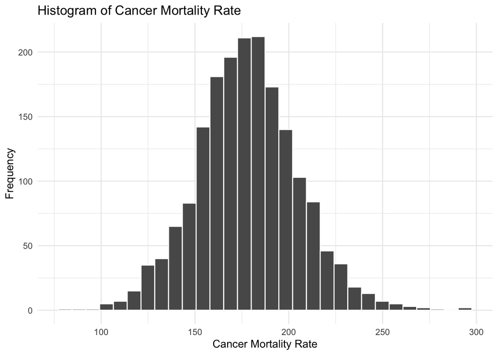

```r
ggplot2::ggplot(cancer_train) + # ggplot(`data.frame object`)
  ggplot2::aes(x = TARGET_deathRate) + # should generally be column names in data.frame
  ggplot2::geom_histogram(color = "white") + # type of geom_* to show
  ggplot2::labs( # labels for axes and title
    x = "Cancer Mortality Rate",
    y = "Frequency",
    title = "Histogram of Cancer Mortality Rate"
  ) +
  ggplot2::theme_minimal() # add theme for better aesthetics
```

**X Distributions**

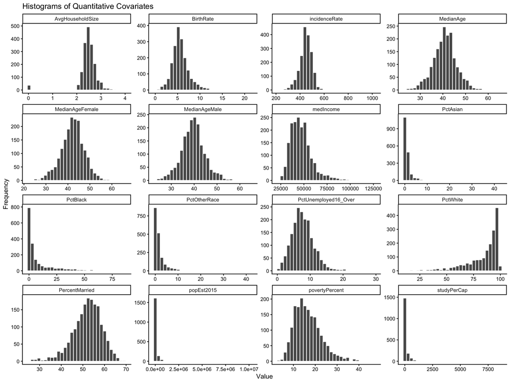

```r
# convert cancer data from "wide" format to "long" format for ggplot
plt_df <- cancer_train |>
  tidyr::pivot_longer(
    cols = -TARGET_deathRate,
    names_to = "variable",
    values_to = "value"
  )
ggplot2::ggplot(plt_df) +
  ggplot2::aes(x = value) +
  ggplot2::geom_histogram(color = "white") +
  # facet by variable name, allowing axis scales to vary
  ggplot2::facet_wrap(~ variable, scales = "free", ncol = 4) +
  ggplot2::labs(
    x = "Value",
    y = "Frequency",
    title = "Histograms of Quantitative Covariates"
  ) +
  ggplot2::theme_classic()
```

**Correlations**

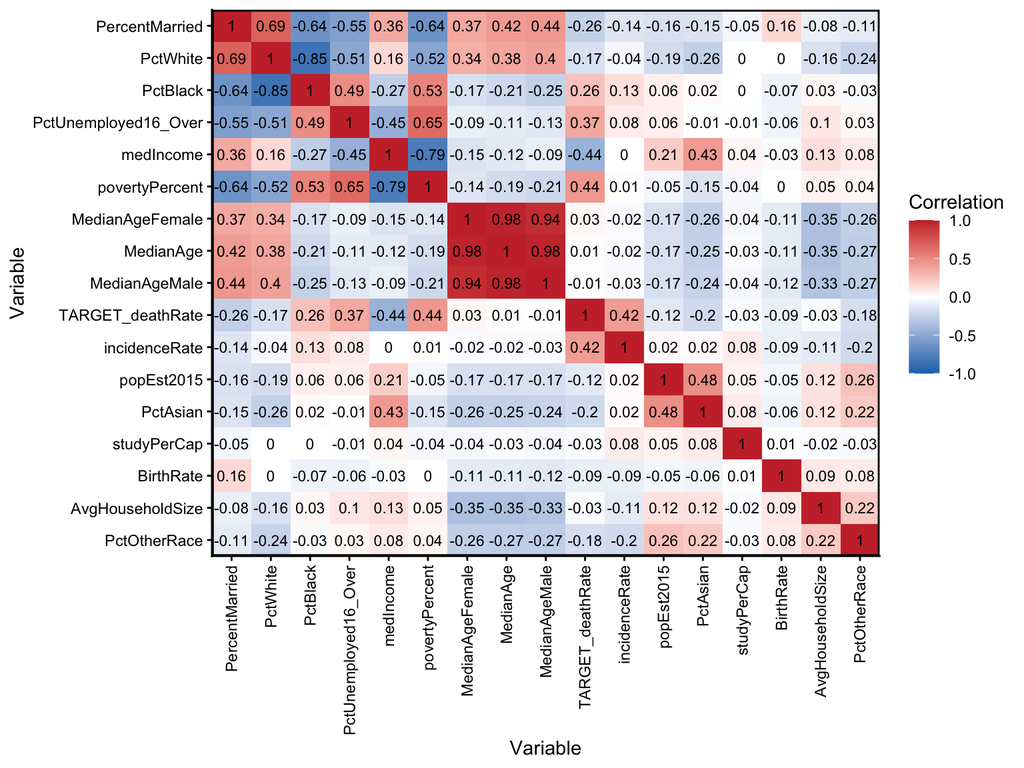

```r
ggwrappers::plot_cor_heatmap(cancer_train, text_size = 3) +
  ggplot2::labs(fill = "Correlation", x = "Variable", y = "Variable") +
  ggplot2::theme(
    axis.text.x = ggplot2::element_text(angle = 90, hjust = 1, vjust = 0.5)
  )
```

**Relationship Between Response and Predictors**

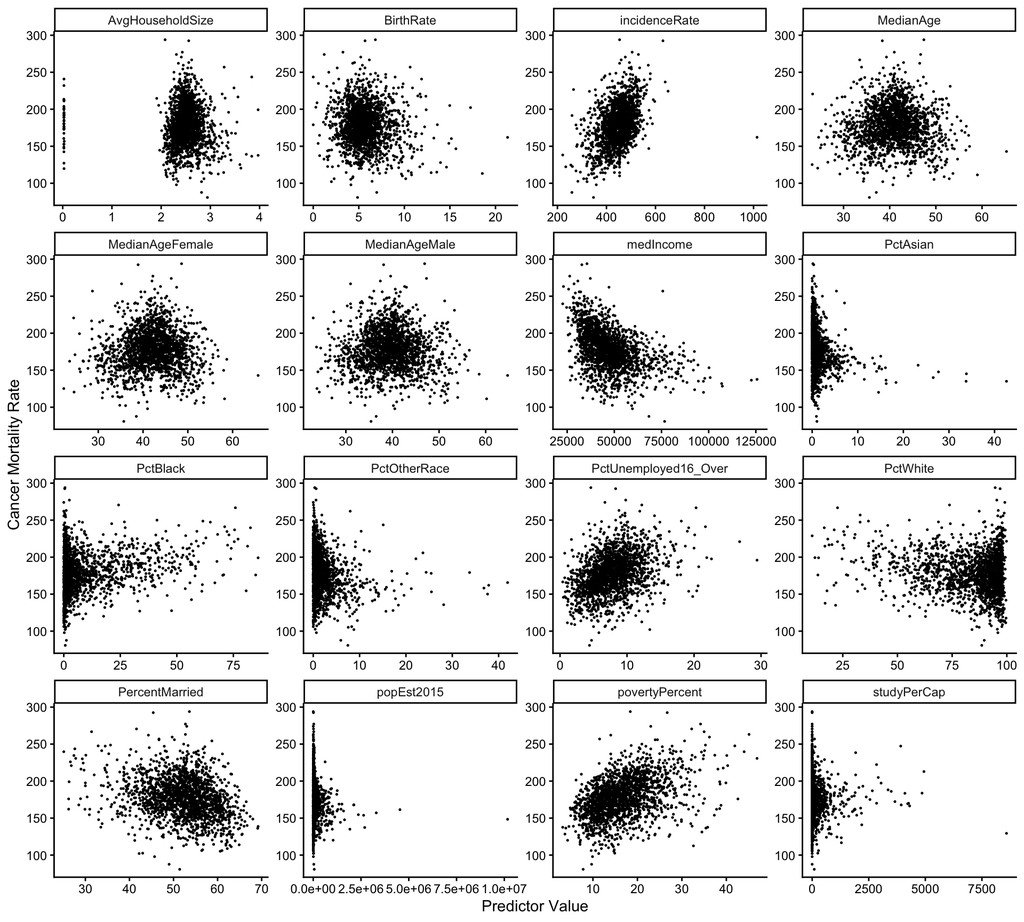

```r
# convert cancer data from "wide" format to "long" format for ggplot
plt_df <- cancer_train |>
  tidyr::pivot_longer(
    cols = -TARGET_deathRate,
    names_to = "variable",
    values_to = "value"
  )
ggplot2::ggplot(plt_df) +
  ggplot2::aes(x = value, y = TARGET_deathRate) +
  ggplot2::geom_point(size = 0.25) +
  # facet by variable name, allowing axis scales to vary
  ggplot2::facet_wrap(~ variable, scales = "free", ncol = 4) +
  ggplot2::labs(
    x = "Predictor Value",
    y = "Cancer Mortality Rate"
  ) +
  ggplot2::theme_classic()
```

## Modeling

For the sake of demonstration, we will fit a linear regression model, a LASSO regression model, and a random forest model to predict cancer mortality rates.

```r
# linear regression model with all predictors
lm_model <- lm(TARGET_deathRate ~ ., data = cancer_train)
summary(lm_model)
```

```
Call:
lm(formula = TARGET_deathRate ~ ., data = cancer_train)

Residuals:
     Min       1Q   Median       3Q      Max
-131.716  -12.193   -0.206   12.200  111.999

Coefficients:
                       Estimate Std. Error t value Pr(>|t|)
(Intercept)           8.439e+01  1.431e+01   5.896 4.44e-09 ***
incidenceRate         2.088e-01  9.714e-03  21.493  < 2e-16 ***
popEst2015           -2.888e-06  1.636e-06  -1.765   0.0777 .
BirthRate            -1.074e+00  2.585e-01  -4.156 3.39e-05 ***
medIncome            -5.485e-04  8.646e-05  -6.344 2.82e-10 ***
povertyPercent        7.597e-01  1.891e-01   4.017 6.14e-05 ***
studyPerCap          -2.085e-03  9.933e-04  -2.100   0.0359 *
MedianAge             8.748e-01  1.474e+00   0.593   0.5530
MedianAgeMale        -9.015e-01  8.446e-01  -1.067   0.2860
MedianAgeFemale      -1.011e-01  7.293e-01  -0.139   0.8897
AvgHouseholdSize      3.129e+00  1.261e+00   2.482   0.0132 *
PercentMarried        3.695e-01  1.271e-01   2.907   0.0037 **
PctUnemployed16_Over  1.040e+00  2.002e-01   5.195 2.28e-07 ***
PctWhite             -9.945e-02  7.860e-02  -1.265   0.2059
PctBlack             -5.429e-02  7.728e-02  -0.702   0.4825
PctAsian             -4.863e-01  2.618e-01  -1.858   0.0634 .
PctOtherRace         -6.564e-01  1.646e-01  -3.988 6.93e-05 ***
---
Signif. codes:  0 '***' 0.001 '**' 0.01 '*' 0.05 '.' 0.1 ' ' 1

Residual standard error: 20.64 on 1811 degrees of freedom
Multiple R-squared:  0.4237,    Adjusted R-squared:  0.4186
F-statistic: 83.21 on 16 and 1811 DF,  p-value: < 2.2e-16
```

```r
lm_preds_valid <- predict(lm_model, newdata = cancer_valid)
```

```r
# LASSO regression model with all predictors
lasso_model <- glmnet::cv.glmnet(
  x = cancer_train |> dplyr::select(-TARGET_deathRate) |> as.matrix(),
  y = cancer_train$TARGET_deathRate,
  alpha = 1
)
lasso_preds_valid <- predict(
  lasso_model,
  newx = cancer_valid |> dplyr::select(-TARGET_deathRate) |> as.matrix(),
  s = "lambda.min"
)
```

```r
# random forest model with all predictors
rf_model <- ranger::ranger(
  formula = TARGET_deathRate ~ .,
  data = cancer_train,
  num.trees = 500,
  mtry = floor(sqrt(ncol(cancer_train) - 1)),
  min.node.size = 5
)
rf_preds_valid <- predict(rf_model, data = cancer_valid)$predictions
```

```r
metrics <- list(
  "RMSE" = yardstick::rmse_vec,
  "R2" = yardstick::rsq_vec,
  "MAE" = yardstick::mae_vec
)
preds_valid_ls <- list(
  "OLS" = lm_preds_valid,
  "LASSO" = as.vector(lasso_preds_valid),
  "RF" = rf_preds_valid
)
valid_metrics <- purrr::map(
  preds_valid_ls,
  function(preds) {
    purrr::map_dbl(metrics, ~ .x(cancer_valid$TARGET_deathRate, preds))
  }
) |>
  dplyr::bind_rows(.id = "model")
print(valid_metrics)
```

```
# A tibble: 3 × 4
  model  RMSE    R2   MAE
  <chr> <dbl> <dbl> <dbl>
1 OLS    21.4 0.457  16.1
2 LASSO  21.4 0.457  16.1
3 RF     20.9 0.489  15.3
```

## Prediction on test set

```r
# re-fit best model on all training data (i.e., training + validation)
rf_model <- ranger::ranger(
  formula = TARGET_deathRate ~ .,
  data = rbind(cancer_train, cancer_valid),
  num.trees = 500,
  mtry = floor(sqrt(ncol(cancer_train) - 1)),
  min.node.size = 5
)
# predict on test set
preds_test <- predict(rf_model, data = cancer_test)$predictions
# save predictions to file
RESULTS_DIR <- here::here("results")
if (!dir.exists(RESULTS_DIR)) {
  dir.create(RESULTS_DIR)
}
write.csv(
  preds_test,
  file.path(RESULTS_DIR, "test_predictions.csv"),
  row.names = FALSE
)
```

```r
# # TODO: UNCOMMENT LATER AND REMOVE `eval: false` TO EVALUATE TEST PREDICTIONS
# # read in true test labels
# test_labels <- readr::read_csv(
#   file.path(DATA_DIR, "cancer_test_labels.csv")
# )
# # compute test metrics
# test_metrics <- purrr::map_dbl(
#   metrics, ~ .x(test_labels$TARGET_deathRate, preds_test)
# )
# print(test_metrics)
```